# Regression Assumptions &amp; Diagnostics

←Back to the bookChapter 95 · Regression Assumptions & Diagnostics

Chapter 95 · Regression Assumptions & Diagnostics

Regression Assumptions & Diagnostics

Build the residual dashboard, run Breusch-Pagan / Jarque-Bera / Durbin-Watson, measure influence with Cook's distance, and fix a real model with a log transform, all library-first with statsmodels.

Statistics, Data Science and AI: A Visual Handbook · John Fisher · 2026

## Regression diagnostics: checking (and fixing) the LINE assumptions

Library-first: `statsmodels` supplies the residual dashboard, the formal tests, and the influence measures. We diagnose a naive insurance model, expose two violations, cure them with one log transform, and hunt for influential points.

```python
import numpy as np, pandas as pd, matplotlib.pyplot as plt
from scipy import stats
import seaborn as sns   # seaborn = high-level statistical plots (heatmaps, regplots, pairplots)
import statsmodels.api as sm
from statsmodels.formula.api import ols
from statsmodels.stats.outliers_influence import variance_inflation_factor
from statsmodels.nonparametric.smoothers_lowess import lowess
from sklearn.linear_model import LinearRegression, Ridge, Lasso, LogisticRegression
from sklearn.preprocessing import StandardScaler, PolynomialFeatures
from sklearn.pipeline import make_pipeline
from sklearn.model_selection import train_test_split, cross_val_score
from sklearn.metrics import r2_score, mean_squared_error
ORG="#ea580c"; DEEP="#c2410c"; LIGHT="#fdba74"; INK="#1a2138"; GRID="#e6e9f2"; GREEN="#059669"; RED="#ef4444"; AMBER="#d97706"; BLUE="#2563eb"; PUR="#9333ea"; GREY="#94a3b8"; SLATE="#475569"
plt.rcParams.update({"figure.facecolor":"white","axes.facecolor":"white","figure.dpi":110,"font.size":11,
   "axes.edgecolor":GRID,"axes.grid":True,"grid.color":GRID,"axes.axisbelow":True,"axes.spines.top":False,
   "axes.spines.right":False,"axes.titlesize":12,"axes.titleweight":"bold","legend.frameon":False})
sns.set_style("whitegrid")
BASE="https://raw.githubusercontent.com/johnfisher-ai/Statistics-Data-Science-AI-Visual-Book/main/data/"
```

DEMO 1 · FIT & DASHBOARD

The four-plot diagnostic dashboard

Fit charges on age, BMI, and smoking, then build the classic residual dashboard.

```python
try:
    ins = pd.read_excel('../../data/regression-assumptions-and-diagnostics--insurance.xlsx', sheet_name='Policies')
except FileNotFoundError:
    ins = pd.read_excel(BASE + 'regression-assumptions-and-diagnostics--insurance.xlsx', sheet_name='Policies')
print(ins.shape); ins.head(3)
```

```
(300, 5)
```

|  | policy_id | age | bmi | smoker | charges |
| --- | --- | --- | --- | --- | --- |
| 0 | P2000 | 39 | 29.0 | no | 5445.32 |
| 1 | P2001 | 43 | 17.1 | no | 4725.71 |
| 2 | P2002 | 20 | 36.5 | no | 3894.55 |

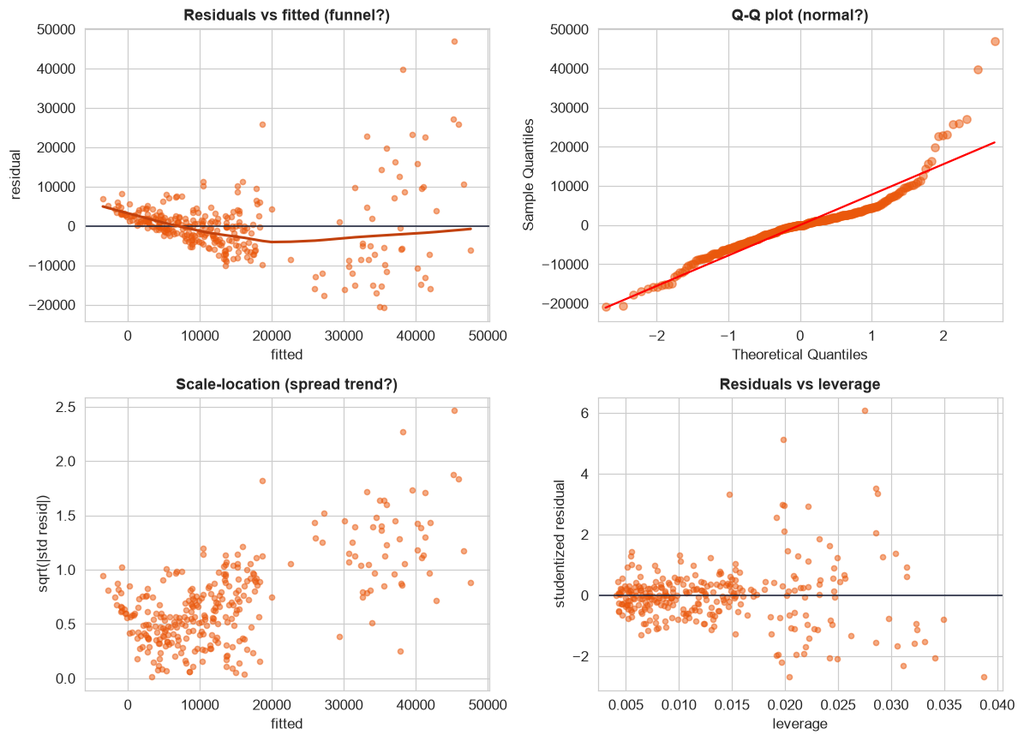

```python
m = ols('charges ~ age + bmi + C(smoker)', ins).fit()
resid, fitted = m.resid, m.fittedvalues
infl = m.get_influence(); stud = infl.resid_studentized_internal
fig, ax = plt.subplots(2, 2, figsize=(11,8))
ax[0,0].scatter(fitted, resid, s=16, color=ORG, alpha=0.5); ax[0,0].axhline(0,color=INK,lw=1)
lo = lowess(resid, fitted, frac=0.6); ax[0,0].plot(lo[:,0], lo[:,1], color=DEEP, lw=2)
ax[0,0].set(title='Residuals vs fitted (funnel?)', xlabel='fitted', ylabel='residual')
sm.qqplot(resid, line='s', ax=ax[0,1], markerfacecolor=ORG, markeredgecolor=ORG, alpha=0.5)
ax[0,1].set_title('Q-Q plot (normal?)')
ax[1,0].scatter(fitted, np.sqrt(np.abs(stud)), s=16, color=ORG, alpha=0.5)
ax[1,0].set(title='Scale-location (spread trend?)', xlabel='fitted', ylabel='sqrt(|std resid|)')
ax[1,1].scatter(infl.hat_matrix_diag, stud, s=16, color=ORG, alpha=0.5); ax[1,1].axhline(0,color=INK,lw=1)
ax[1,1].set(title='Residuals vs leverage', xlabel='leverage', ylabel='studentized residual')
plt.tight_layout(); plt.show()
```

DEMO 2 · STEP 4 TESTS

Turn the plots into pass/fail decisions

Breusch-Pagan, Jarque-Bera, and Durbin-Watson put numbers on what the dashboard hints.

```python
from statsmodels.stats.diagnostic import het_breuschpagan
from statsmodels.stats.stattools import jarque_bera, durbin_watson
def report(model, name):
    bp = het_breuschpagan(model.resid, model.model.exog)[1]
    jb = jarque_bera(model.resid)[1]
    dw = durbin_watson(model.resid)
    print(f'{name:14s} R2={model.rsquared:.3f} | BP p={bp:.4f} {"OK" if bp>.05 else "FAIL"} | JB p={jb:.4f} {"OK" if jb>.05 else "FAIL"} | DW={dw:.2f}')
report(m, 'charges')
```

```
charges        R2=0.701 | BP p=0.0000 FAIL | JB p=0.0000 FAIL | DW=2.17
```

**Reading the three tests.** Each turns a residual plot into a yes/no decision:

- **Breusch-Pagan** tests equal variance. A p-value below 0.05 means the spread of the residuals changes with the fitted value (the funnel), so the assumption FAILS.
- **Jarque-Bera** tests normality of the residuals. Below 0.05 means they are too skewed or heavy-tailed to be Normal.
- **Durbin-Watson** tests independence. It runs 0 to 4; near 2 is good, far from 2 signals residuals that track each other (autocorrelation).

For the raw-dollar model both Breusch-Pagan and Jarque-Bera fail, confirming the funnel and skew from the dashboard. Durbin-Watson is fine because the rows are independent policies.

DEMO 3 · THE FIX

One log transform repairs both violations

Model log(charges) and re-run the same checks, the funnel flattens and the Q-Q straightens.

```
charges        R2=0.701 | BP p=0.0000 FAIL | JB p=0.0000 FAIL | DW=2.17
log(charges)   R2=0.781 | BP p=0.8794 OK | JB p=0.4984 OK | DW=1.94
```

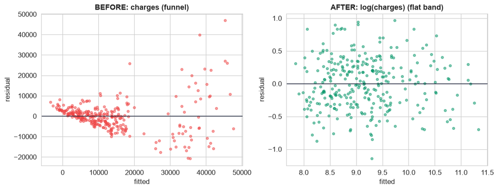

```python
mlog = ols('np.log(charges) ~ age + bmi + C(smoker)', ins).fit()
report(m,    'charges')
report(mlog, 'log(charges)')
fig, ax = plt.subplots(1, 2, figsize=(11,4.3))
ax[0].scatter(m.fittedvalues, m.resid, s=14, color=RED, alpha=0.5); ax[0].axhline(0,color=INK,lw=1)
ax[0].set(title='BEFORE: charges (funnel)', xlabel='fitted', ylabel='residual')
ax[1].scatter(mlog.fittedvalues, mlog.resid, s=14, color=GREEN, alpha=0.5); ax[1].axhline(0,color=INK,lw=1)
ax[1].set(title='AFTER: log(charges) (flat band)', xlabel='fitted', ylabel='residual')
plt.tight_layout(); plt.show()
```

```python
# Interpret the log-scale coefficients as percentage / multiplicative effects
print('log(charges) coefficients:')
for k,v in mlog.params.items():
    print(f'  {k:20s} {v:+.4f}   -> x{np.exp(v):.2f} per unit')
print(f"\nSmokers pay about {np.exp(mlog.params['C(smoker)[T.yes]']):.1f}x more, all else equal.")
```

```
log(charges) coefficients:
  Intercept            +6.6207   -> x750.48 per unit
  C(smoker)[T.yes]     +1.4650   -> x4.33 per unit
  age                  +0.0324   -> x1.03 per unit
  bmi                  +0.0308   -> x1.03 per unit

Smokers pay about 4.3x more, all else equal.
```

DEMO 4 · INFLUENCE

Leverage, Cook's distance, and a robustness check

Find the points that most move the fit, then confirm the conclusions survive without them.

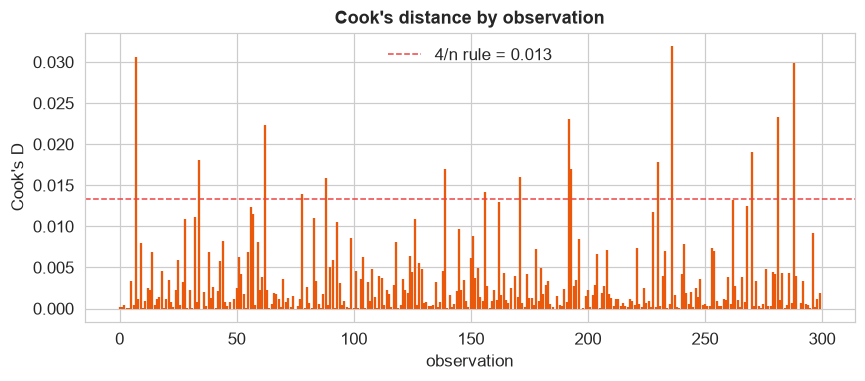

```
15 points exceed the 4/n rule; max Cook D = 0.032
```

```python
infl = mlog.get_influence(); cook = infl.cooks_distance[0]
fig, ax = plt.subplots(figsize=(8,3.6))
ax.stem(np.arange(len(cook)), cook, linefmt=ORG, markerfmt=' ', basefmt=' ')
thr = 4/len(ins)
ax.axhline(thr, color=RED, ls='--', lw=1, label=f'4/n rule = {thr:.3f}')
ax.set(title="Cook's distance by observation", xlabel='observation', ylabel="Cook's D"); ax.legend()
plt.tight_layout(); plt.show()
flag = np.where(cook > thr)[0]
print(f'{len(flag)} points exceed the 4/n rule; max Cook D = {cook.max():.3f}')
```

```python
# Robustness: drop the flagged points and refit; do the coefficients hold?
keep = ~ins.index.isin(flag)
refit = ols('np.log(charges) ~ age + bmi + C(smoker)', ins[keep]).fit()
comp = pd.DataFrame({'all': mlog.params.round(4), 'without_influential': refit.params.round(4)})
print(comp)
print('\nCoefficients barely move: the conclusions do not hinge on a few points.')
```

```
                     all  without_influential
Intercept         6.6207               6.6073
C(smoker)[T.yes]  1.4650               1.4694
age               0.0324               0.0337
bmi               0.0308               0.0296

Coefficients barely move: the conclusions do not hinge on a few points.
```

## Putting it all together: the diagnostic workflow

This chapter is steps 1 and 4 of the workflow up close. Here is the full run and how each tool was used.

**Step 1, explore.** The charges distribution is heavily right-skewed, a long tail of expensive policies. A skewed, positive response is a red flag for the equal-variance and normality assumptions before we even fit.

**Step 2, fit.** We fit charges ~ age + bmi + C(smoker) in raw dollars, which posted a respectable R-squared of 0.70.

**Steps 3-4, evaluate and check the conditions.** The four-plot dashboard (residuals-vs-fitted, Q-Q, scale-location, residuals-vs-leverage) is the analyst's first look. We then made the decision formal: **Breusch-Pagan** (equal variance) and **Jarque-Bera** (normality) both failed for the raw model, while **Durbin-Watson** (independence) was fine.

**The remedy.** Because the response was skewed and positive, we modeled **log(charges)**. Re-running the same checks, the funnel flattened, the Q-Q straightened, both tests now passed, and R-squared even rose from 0.70 to 0.78. That is the feedback loop: diagnose, apply the matching fix, re-check.

**Influence.** Leverage measures an unusual x, a large residual an unusual y; **Cook's distance** combines them to flag points that actually move the fit. We flagged the highest-Cook's-distance policies with the 4/n rule, dropped them, and re-fit, the coefficients barely moved, so the conclusions do not hinge on a few rows. (Investigate influential points; do not blindly delete them.)

**Interpretation.** On the log scale a coefficient b means the response multiplies by e^b per unit: age adds about 3.2% per year, BMI about 3.1% per point, and being a smoker multiplies charges by about 4.3x, the biggest driver. To predict a dollar amount, exponentiate the log-scale prediction.

**Takeaway.** A high R-squared does not certify a model. The residual diagnostics are what let you trust the standard errors, p-values, and intervals; when they fail, a transform or a robust method is the cure.

Statistics, Data Science and AI: A Visual Handbook · © 2026 John Fisher

←Back to the bookChapter 95 · Regression Assumptions & Diagnostics